# Antes de empezar:

```
Lee el archivo README.md
Comenta todo lo que puedas y utiliza los recursos (archivo README.md)
¡Feliz aprendizaje!
```

En este ejercicio, generaremos números aleatorios a partir de las disribuciones continuas que aprendimos en la lección. Hay dos formas de generar números aleatorios:

1. Usando la librería numpy
2. Usando la librería Scipy

Utiliza cualquiera de las dos librerías o ambas en este ejercicio.

```python
import matplotlib.pyplot as plt
import pandas as pd
import numpy as np
import math
import seaborn as sns
```

## Distribución Uniforme

```python
# your code here
```

**Tarea:**

1. Basándote en el código anterior, escribe una función que genere números aleatorios uniformemente distribuidos. Hay varios requisitos para tu función:
   - Debe aceptar 3 parámetros:
     - `bottom` - el límite inferior de los números generados
     - `ceiling` - el límite superior de los números generados
     - `count` - cuántos números generar
   - Debe devolver una matriz de números aleatorios distribuidos uniformemente
2. Llama a tu función con 2 conjuntos de parámetros a continuación:
   - bottom=10, ceiling=15, count=100
   - bottom=10, ceiling=60, count=1,000
3. Traza las distribuciones uniformes generadas anteriormente utilizando histogramas, donde el eje x es el valor y el eje y es el recuento. Que el número de intervalos del histograma sea 10.

El resultado debe ser como el siguiente:

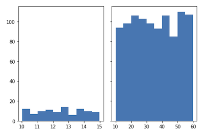

```python
# your code here
```

```python
# your code here
```

```python
# your code here
```

How are the two distributions different?

```python
# your answer below
```

## Distribución Normal

1. De la misma manera en el reto de Distribución Uniforme, escriba una función que genere números aleatorios distribuidos normalmente.
2. Genera 1.000 números distribuidos normalmente con media de 10 y desviación típica de 1
3. Genera 1.000 números distribuidos normalmente con una media de 10 y una desviación típica de 50
4. Representa gráficamente las distribuciones de los datos generados.

Resultado esperado:

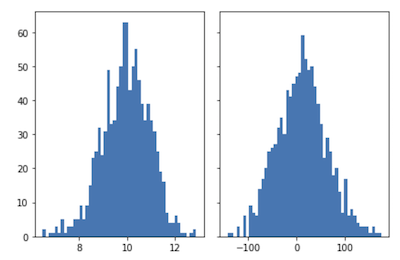

```python
from scipy.stats import norm
```

```python
# your code here
```

```python
# your code here
```

```python
# your code here
```

```python
# your code here
```

How are the two distributions different?

## Distribución Normal de Datos Reales

En este reto vamos a echar un vistazo a los datos reales. Utilizaremos el archivo vehicles.csv para este ejercicio

```python
# your code here
```

Primero importa vehicles.csv. A continuación, traza los histogramas de las siguientes variables:

1. Barriles de combustible/año

```python
# your code here
```

```python
# your code here
```

2. Emisiones de CO2 Gramos/Milla

```python
# your code here
```

```python
# your code here
```

3. MPG combinado

```python
# your code here
```

```python
# your code here
```

```python
# your code here
```

¿Cuál o cuáles de las variables tienen una distribución casi normal? ¿Cómo lo sabes?

```python
# your code here
```

```python
# your code here
```

```python
# your code here
```

```python
# your code here
```

## Distribución Exponencial

El resultado debe ser como el siguiente:

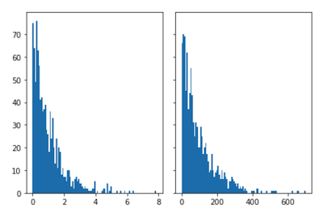

```python
# your code here
```

¿En qué se diferencian ambas distribuciones?

## Distribución Exponencial de datos reales

Supongamos que el tiempo que uno pasa en un banco se distribuye exponencialmente con media de 10 minutos (es decir, λ = 1/10). ¿Cuál es la probabilidad de que un cliente pase menos de quince minutos en el banco?

Escribe un código en python para resolver este problema

```python
# your code here
```

```python
# your answer here
# Hint: This is same as saying P(x<15)
```

¿Cuál es la probabilidad de que el cliente pase más de 15 minutos?

```python
# your code here
```